```python
# Allow multiple output/display from one cell
from IPython.core.interactiveshell import InteractiveShell
InteractiveShell.ast_node_interactivity = "all"
```

# Data Manipulation with Pandas

Pandas is a newer package built on top of NumPy, and provides an efficient implementation of a `DataFrame`. `DataFrame`s are essentially multidimensional arrays with attached row and column labels.

Pandas, and in particular its `Series` and `DataFrame` objects, provides efficient access to these sorts of "data munging" tasks.

The newest verion of Pandas released in Jan 29, 2020 is 1.0.0. The many useful documents related to this new version of Pandas can be found at the [pandas.pydata.org websit](https://pandas.pydata.org/pandas-docs/version/1.0.0/index.html).

```python
import pandas
pandas.__version__
```

```
'0.25.3'
```

# Introducing Pandas Objects

At the very basic level, Pandas objects can be thought of as enhanced versions of NumPy structured arrays in which the rows and columns are identified with labels rather than simple integer index. We will go through these three fundamental Pandas data structures: the `Series`, `DataFrame`, and `Index`.

```python
# We will start our code sessions with the standard NumPy and Pandas imports:
import numpy as np
import pandas as pd
```

## The Pandas Series Object

A Pandas `Series` is a one-dimensional array of indexed data. It can be created from a list or array as follows:

```python
data = pd.Series([0.25, 0.5, 0.75, 1.0])
data
```

```
0    0.25
1    0.50
2    0.75
3    1.00
dtype: float64
```

The `Series` wraps both a sequence of values and a sequence of indices, which we can access with the `values` and `index` attributes. The `values` are simply a familiar NumPy array:

```python
data.values
```

```
array([0.25, 0.5 , 0.75, 1.  ])
```

The `index` is an array-like object of type `pd.Index`

```python
data.index
```

```
RangeIndex(start=0, stop=4, step=1)
```

Like with a NumPy array, data can be accessed by the associated index:

```python
data[1]
```

```
0.5
```

```python
data[1:3]
```

```
1    0.50
2    0.75
dtype: float64
```

### Series as generalized NumPy array

```python
data = pd.Series([0.25, 0.5, 0.75, 1.0],
                 index=['a', 'b', 'c', 'd'])
data
```

```
a    0.25
b    0.50
c    0.75
d    1.00
dtype: float64
```

```python
data['b']
```

```
0.5
```

```python
data = pd.Series([0.25, 0.5, 0.75, 1.0],
                 index=[2, 5, 3, 7])
data
```

```
2    0.25
5    0.50
3    0.75
7    1.00
dtype: float64
```

```python
data[5]
```

```
0.5
```

### Series as specialized dictionary

```python
population_dict = {'California': 38332521,
                   'Texas': 26448193,
                   'New York': 19651127,
                   'Florida': 19552860,
                   'Illinois': 12882135}
population = pd.Series(population_dict)
population
```

```
California    38332521
Texas         26448193
New York      19651127
Florida       19552860
Illinois      12882135
dtype: int64
```

```python
population['California']
```

```
38332521
```

Unlike a dictionary, though, the `Series` also supports array-style operations such as slicing:

```python
population['California':'Illinois']
```

```
California    38332521
Texas         26448193
New York      19651127
Florida       19552860
Illinois      12882135
dtype: int64
```

### Constructing Series objects

```python
pd.Series([2, 4, 6])
```

```
0    2
1    4
2    6
dtype: int64
```

```python
pd.Series(5, index=[100, 200, 300])
```

```
100    5
200    5
300    5
dtype: int64
```

```python
pd.Series({2:'a', 1:'b', 3:'c'})
```

```
2    a
1    b
3    c
dtype: object
```

```python
pd.Series({2:'a', 1:'b', 3:'c'}, index=[3, 2])
```

```
3    c
2    a
dtype: object
```

## The Pandas DataFrame Object

Like the `Series` object discussed in the previous section, the `DataFrame` can be thought of either as a generalization of a NumPy array, or as a specialization of a Python dictionary.

### Constructing DataFrame objects

A Pandas `DataFrame` can be constructed in a variety of ways.

**From a single Series object**

```python
pd.DataFrame(population, columns=['population'])
```

|  | population |
| --- | --- |
| California | 38332521 |
| Texas | 26448193 |
| New York | 19651127 |
| Florida | 19552860 |
| Illinois | 12882135 |

**From a list of dicts**

```python
data = [{'a': i, 'b': 2 * i} for i in range(3)]
pd.DataFrame(data)
```

|  | a | b |
| --- | --- | --- |
| 0 | 0 | 0 |
| 1 | 1 | 2 |
| 2 | 2 | 4 |

Even if some keys in the dictionary are missing, Pandas will fill them in with `NaN` (i.e., "not a number") values:

```python
pd.DataFrame([{'a': 1, 'b': 2}, {'b': 3, 'c': 4}])
```

|  | a | b | c |
| --- | --- | --- | --- |
| 0 | 1.0 | 2 | NaN |
| 1 | NaN | 3 | 4.0 |

**From a dictionary of Series objects**

```python
pd.DataFrame({'population': population,'area': area})
```

[output not shown]

**From a two-dimensional NumPy array**

```python
pd.DataFrame(np.random.rand(3, 2),
             columns=['foo', 'bar'],
             index=['a', 'b', 'c'])
```

|  | foo | bar |
| --- | --- | --- |
| a | 0.895658 | 0.190124 |
| b | 0.567381 | 0.846256 |
| c | 0.806054 | 0.886547 |

**From a NumPy structured array**

```python
A = np.zeros(3, dtype=[('A', 'i8'), ('B', 'f8')])
A
```

```
array([(0, 0.), (0, 0.), (0, 0.)], dtype=[('A', '<i8'), ('B', '<f8')])
```

```python
pd.DataFrame(A)
```

|  | A | B |
| --- | --- | --- |
| 0 | 0 | 0.0 |
| 1 | 0 | 0.0 |
| 2 | 0 | 0.0 |

### DataFrame as a generalized NumPy array

If a `Series` is an analog of a one-dimensional array with flexible indices, a `DataFrame` is an analog of a two-dimensional array with both flexible row indices and flexible column names.

```python
area_dict = {'California': 423967, 'Texas': 695662, 'New York': 141297,
             'Florida': 170312, 'Illinois': 149995}
area = pd.Series(area_dict)
area
```

```
California    423967
Texas         695662
New York      141297
Florida       170312
Illinois      149995
dtype: int64
```

```python
states = pd.DataFrame({'population': population,
                       'area': area})
states
```

|  | population | area |
| --- | --- | --- |
| California | 38332521 | 423967 |
| Texas | 26448193 | 695662 |
| New York | 19651127 | 141297 |
| Florida | 19552860 | 170312 |
| Illinois | 12882135 | 149995 |

Like the `Series` object, the `DataFrame` has an `index` attribute that gives access to the index labels:

```python
states.index
```

```
Index(['California', 'Texas', 'New York', 'Florida', 'Illinois'], dtype='object')
```

```python
states.columns
```

```
Index(['population', 'area'], dtype='object')
```

### DataFrame as specialized dictionary

Similarly, `DataFrame` can be considered as a specialization of a dictionary.

```python
states['area']
```

```
California    423967
Texas         695662
New York      141297
Florida       170312
Illinois      149995
Name: area, dtype: int64
```

## The Pandas Index Object

This `Index` object is an interesting structure in itself, and it can be thought of either as an *immutable array* or as an *ordered set* (technically a multi-set, as `Index` objects may contain repeated values).

```python
ind = pd.Index([2, 3, 5, 7, 11])
ind
```

```
Int64Index([2, 3, 5, 7, 11], dtype='int64')
```

### Index as immutable array

```python
ind[1]
```

```
3
```

```python
ind[::2]
```

```
Int64Index([2, 5, 11], dtype='int64')
```

```python
print(ind.size, ind.shape, ind.ndim, ind.dtype)
```

```
5 (5,) 1 int64
```

One difference between `Index` objects and NumPy arrays is that indices are immutable–that is, they cannot be modified via the normal means:

```
ind[1] = 0

---------------------------------------------------------------------------
TypeError                                 Traceback (most recent call last)
<ipython-input-34-40e631c82e8a> in <module>()
----> 1 ind[1] = 0

/Users/jakevdp/anaconda/lib/python3.5/site-packages/pandas/indexes/base.py in __setitem__(self, key, value)
   1243
   1244     def __setitem__(self, key, value):
-> 1245         raise TypeError("Index does not support mutable operations")
   1246
   1247     def __getitem__(self, key):

TypeError: Index does not support mutable operations
```

This immutability makes it safer to share indices between multiple `DataFrame`s and arrays, without the potential for side effects from inadvertent index modification.

### Index as ordered set

```python
indA = pd.Index([1, 3, 5, 7, 9])
indB = pd.Index([2, 3, 5, 7, 11])
```

```python
indA & indB  # intersection
```

```
Int64Index([3, 5, 7], dtype='int64')
```

```python
indA | indB  # union
```

```
Int64Index([1, 2, 3, 5, 7, 9, 11], dtype='int64')
```

```python
indA ^ indB  # symmetric difference
```

```
Int64Index([1, 2, 9, 11], dtype='int64')
```

These operations may also be accessed via object methods, for example `indA.intersection(indB)`.

# Data Indexing and Selection

## Data Selection in Series

### Series as dictionary

```python
import pandas as pd
data = pd.Series([0.25, 0.5, 0.75, 1.0],
                 index=['a', 'b', 'c', 'd'])
data
```

```
a    0.25
b    0.50
c    0.75
d    1.00
dtype: float64
```

```python
data['b']
```

```
0.5
```

```python
'a' in data
```

```
True
```

```python
data.keys()
```

```
Index(['a', 'b', 'c', 'd'], dtype='object')
```

```python
list(data.items())
```

```
[('a', 0.25), ('b', 0.5), ('c', 0.75), ('d', 1.0)]
```

`Series` objects can even be modified with a dictionary-like syntax. Just as you can extend a dictionary by assigning to a new key, you can extend a `Series` by assigning to a new index value:

```python
data['e'] = 1.25
data
```

```
a    0.25
b    0.50
c    0.75
d    1.00
e    1.25
dtype: float64
```

### Series as one-dimensional array

```python
# slicing by explicit index
data['a':'c']
```

```
a    0.25
b    0.50
c    0.75
dtype: float64
```

```python
# slicing by implicit integer index
data[0:2]
```

```
a    0.25
b    0.50
dtype: float64
```

```python
# masking
data[(data > 0.3) & (data < 0.8)]
```

```
b    0.50
c    0.75
dtype: float64
```

```python
# fancy indexing
data[['a', 'e']]
```

```
a    0.25
e    1.25
dtype: float64
```

Notice that when slicing with an explicit index (i.e., `data['a':'c']`), the final index is *included* in the slice, while when slicing with an implicit index (i.e., `data[0:2]`), the final index is *excluded* from the slice.

## Data Selection in DataFrame

### DataFrame as a dictionary

```python
area = pd.Series({'California': 423967, 'Texas': 695662,
                  'New York': 141297, 'Florida': 170312,
                  'Illinois': 149995})
pop = pd.Series({'California': 38332521, 'Texas': 26448193,
                 'New York': 19651127, 'Florida': 19552860,
                 'Illinois': 12882135})
data = pd.DataFrame({'area':area, 'pop':pop})
data
```

|  | area | pop |
| --- | --- | --- |
| California | 423967 | 38332521 |
| Texas | 695662 | 26448193 |
| New York | 141297 | 19651127 |
| Florida | 170312 | 19552860 |
| Illinois | 149995 | 12882135 |

```python
data['area']
```

```
California    423967
Texas         695662
New York      141297
Florida       170312
Illinois      149995
Name: area, dtype: int64
```

```python
data.area
```

```
California    423967
Texas         695662
New York      141297
Florida       170312
Illinois      149995
Name: area, dtype: int64
```

```python
data.area is data['area']
```

```
True
```

Though this is a useful shorthand, keep in mind that it does not work for all cases! For example, if the column names are not strings, or if the column names conflict with methods of the `DataFrame`, this attribute-style access is not possible. For example, the `DataFrame` has a `pop()` method, so `data.pop` will point to this rather than the `"pop"` column:

```python
data.pop is data['pop']
```

```
False
```

Thus, we should avoid the temptation to try column assignment via attribute (i.e., use `data['pop'] = z` rather than `data.pop = z`).

```python
data['density'] = data['pop'] / data['area']
data
```

|  | area | pop | density |
| --- | --- | --- | --- |
| California | 423967 | 38332521 | 90.413926 |
| Texas | 695662 | 26448193 | 38.018740 |
| New York | 141297 | 19651127 | 139.076746 |
| Florida | 170312 | 19552860 | 114.806121 |
| Illinois | 149995 | 12882135 | 85.883763 |

### DataFrame as two-dimensional array

```python
data.values
```

```
array([[4.23967000e+05, 3.83325210e+07, 9.04139261e+01],
       [6.95662000e+05, 2.64481930e+07, 3.80187404e+01],
       [1.41297000e+05, 1.96511270e+07, 1.39076746e+02],
       [1.70312000e+05, 1.95528600e+07, 1.14806121e+02],
       [1.49995000e+05, 1.28821350e+07, 8.58837628e+01]])
```

We can transpose the full `DataFrame` to swap rows and columns:

```python
data.T
```

|  | California | Texas | New York | Florida | Illinois |
| --- | --- | --- | --- | --- | --- |
| area | 4.239670e+05 | 6.956620e+05 | 1.412970e+05 | 1.703120e+05 | 1.499950e+05 |
| pop | 3.833252e+07 | 2.644819e+07 | 1.965113e+07 | 1.955286e+07 | 1.288214e+07 |
| density | 9.041393e+01 | 3.801874e+01 | 1.390767e+02 | 1.148061e+02 | 8.588376e+01 |

```python
data.values[0]
```

```
array([4.23967000e+05, 3.83325210e+07, 9.04139261e+01])
```

```python
data.iloc[:3, :2]
```

|  | area | pop |
| --- | --- | --- |
| California | 423967 | 38332521 |
| Texas | 695662 | 26448193 |
| New York | 141297 | 19651127 |

```python
data.loc[:'Illinois', :'pop']
```

|  | area | pop |
| --- | --- | --- |
| California | 423967 | 38332521 |
| Texas | 695662 | 26448193 |
| New York | 141297 | 19651127 |
| Florida | 170312 | 19552860 |
| Illinois | 149995 | 12882135 |

```python
data.loc[data.density > 100, ['pop', 'density']]
```

|  | pop | density |
| --- | --- | --- |
| New York | 19651127 | 139.076746 |
| Florida | 19552860 | 114.806121 |

```python
data.iloc[0, 2] = 90
data
```

|  | area | pop | density |
| --- | --- | --- | --- |
| California | 423967 | 38332521 | 90.000000 |
| Texas | 695662 | 26448193 | 38.018740 |
| New York | 141297 | 19651127 | 139.076746 |
| Florida | 170312 | 19552860 | 114.806121 |
| Illinois | 149995 | 12882135 | 85.883763 |

### Additional indexing conventions

```python
data['Florida':'Illinois']
```

|  | area | pop | density |
| --- | --- | --- | --- |
| Florida | 170312 | 19552860 | 114.806121 |
| Illinois | 149995 | 12882135 | 85.883763 |

```python
data[1:3]
```

|  | area | pop | density |
| --- | --- | --- | --- |
| Texas | 695662 | 26448193 | 38.018740 |
| New York | 141297 | 19651127 | 139.076746 |

```python
data[data.density > 100]
```

|  | area | pop | density |
| --- | --- | --- | --- |
| New York | 141297 | 19651127 | 139.076746 |
| Florida | 170312 | 19552860 | 114.806121 |

### Simple Data Filtering: query() Function

Pandas includes some tools that allow you to directly access C-speed operations without costly allocation of intermediate arrays. One of these is the `query()` function.

```python
# A simple example
from numpy.random import randn
from pandas import DataFrame

df = pd.DataFrame(randn(10, 2), columns=list('ab'))
df1 = df.query('a > b')
df1
```

|  | a | b |
| --- | --- | --- |
| 4 | -0.180652 | -0.997575 |
| 5 | 1.050269 | 0.971633 |
| 7 | 0.893116 | -0.599585 |
| 8 | 1.201896 | 1.080216 |
| 9 | 0.239428 | -0.135623 |

```python
# use indexing method
df2 = df[df.a > df.b]
df2
```

|  | a | b |
| --- | --- | --- |
| 4 | -0.180652 | -0.997575 |
| 5 | 1.050269 | 0.971633 |
| 7 | 0.893116 | -0.599585 |
| 8 | 1.201896 | 1.080216 |
| 9 | 0.239428 | -0.135623 |

```python
# check if df1 data is the same of df2 data
np.allclose(df1,df2)
```

```
True
```

```python
# more realistic example
import pandas as pd

# making data frame from csv file
data = pd.read_csv("../datasets/rpt_hot_skills.csv")

# replacing blank spaces with '_'
data.columns =[column.replace(" ", "_") for column in data.columns]

# filtering with query method
data.query('master_Term_id == 2', inplace = True)

# display
data
```

|  | minimum | gradient | curve | master_Term_id | best_fit_flag | negative_curve_flag |
| --- | --- | --- | --- | --- | --- | --- |
| 0 | 725.006285 | 7.320000e-07 | 2 | 2 | N | N |
| 1 | 725.006402 | 7.340000e-07 | 1 | 2 | N | N |
| 2 | 725.027231 | 7.470000e-07 | 3 | 2 | N | N |
| 3 | 670.510550 | 0.000000e+00 | 4 | 2 | Y | N |

```python
# filtering with query method
data.query("best_fit_flag == 'N' and negative_curve_flag == 'N'", inplace = True)
data
```

|  | minimum | gradient | curve | master_Term_id | best_fit_flag | negative_curve_flag |
| --- | --- | --- | --- | --- | --- | --- |
| 0 | 725.006285 | 7.320000e-07 | 2 | 2 | N | N |
| 1 | 725.006402 | 7.340000e-07 | 1 | 2 | N | N |
| 2 | 725.027231 | 7.470000e-07 | 3 | 2 | N | N |

## Operating on Data in Pandas

```python
import pandas as pd
import numpy as np
```

```python
rng = np.random.RandomState(42)
ser = pd.Series(rng.randint(0, 10, 4))
ser
```

```
0    6
1    3
2    7
3    4
dtype: int32
```

```python
df = pd.DataFrame(rng.randint(0, 10, (3, 4)),
                  columns=['A', 'B', 'C', 'D'])
df
```

|  | A | B | C | D |
| --- | --- | --- | --- | --- |
| 0 | 6 | 9 | 2 | 6 |
| 1 | 7 | 4 | 3 | 7 |
| 2 | 7 | 2 | 5 | 4 |

If applying a NumPy functions on either of these objects, the result will be another Pandas object *with the indices preserved:

```python
np.exp(ser)
```

```
0     403.428793
1      20.085537
2    1096.633158
3      54.598150
dtype: float64
```

```python
np.sin(df * np.pi / 4)
```

|  | A | B | C | D |
| --- | --- | --- | --- | --- |
| 0 | -1.000000 | 7.071068e-01 | 1.000000 | -1.000000e+00 |
| 1 | -0.707107 | 1.224647e-16 | 0.707107 | -7.071068e-01 |
| 2 | -0.707107 | 1.000000e+00 | -0.707107 | 1.224647e-16 |

### Operations Between DataFrame and Series

```python
A = rng.randint(10, size=(3, 4))
A
```

```
array([[1, 7, 5, 1],
       [4, 0, 9, 5],
       [8, 0, 9, 2]])
```

```python
A - A[0]
```

```
array([[ 0,  0,  0,  0],
       [ 3, -7,  4,  4],
       [ 7, -7,  4,  1]])
```

```python
df = pd.DataFrame(A, columns=list('QRST'))
df - df.iloc[0]
```

|  | Q | R | S | T |
| --- | --- | --- | --- | --- |
| 0 | 0 | 0 | 0 | 0 |
| 1 | 3 | -7 | 4 | 4 |
| 2 | 7 | -7 | 4 | 1 |

```python
df.subtract(df['R'], axis=0)
```

|  | Q | R | S | T |
| --- | --- | --- | --- | --- |
| 0 | -6 | 0 | -2 | -6 |
| 1 | 4 | 0 | 9 | 5 |
| 2 | 8 | 0 | 9 | 2 |

```python
halfrow = df.iloc[0, ::2]
halfrow
```

```
Q    1
S    5
Name: 0, dtype: int32
```

```python
df - halfrow
```

|  | Q | R | S | T |
| --- | --- | --- | --- | --- |
| 0 | 0.0 | NaN | 0.0 | NaN |
| 1 | 3.0 | NaN | 4.0 | NaN |
| 2 | 7.0 | NaN | 4.0 | NaN |

### Pandas String Operations

```python
import numpy as np
x = np.array([2, 3, 5, 7, 11, 13])
x * 2
```

```
array([ 4,  6, 10, 14, 22, 26])
```

```python
data = ['peter', 'Paul', 'MARY', 'gUIDO']
[s.capitalize() for s in data]
```

```
['Peter', 'Paul', 'Mary', 'Guido']
```

Be careful it will break if there are any missing values.

```
data = ['peter', 'Paul', None, 'MARY', 'gUIDO']
[s.capitalize() for s in data]
```

--------------------------------------------------------------------------- AttributeError Traceback (most recent call last) in 1 data = ['peter', 'Paul', None, 'MARY', 'gUIDO'] ----> 2 [s.capitalize() for s in data] in (.0) 1 data = ['peter', 'Paul', None, 'MARY', 'gUIDO'] ----> 2 [s.capitalize() for s in data] AttributeError: 'NoneType' object has no attribute 'capitalize'

Pandas includes features to address both this need for vectorized string operations and for correctly handling missing data via the `str` attribute of Pandas Series and Index objects containing strings.

```python
import pandas as pd
names = pd.Series(data)
names
```

```
0    peter
1     Paul
2     MARY
3    gUIDO
dtype: object
```

```python
names.str.capitalize()
```

```
0    Peter
1     Paul
2     Mary
3    Guido
dtype: object
```

**Tables of Pandas String Methods**

```python
monte = pd.Series(['Graham Chapman', 'John Cleese', 'Terry Gilliam',
                   'Eric Idle', 'Terry Jones', 'Michael Palin'])
```

**Methods similar to Python string methods**

Here is a list of Pandas `str` methods that mirror Python string methods:

| `len()` | `lower()` | `translate()` | `islower()` |
| --- | --- | --- | --- |
| `ljust()` | `upper()` | `startswith()` | `isupper()` |
| `rjust()` | `find()` | `endswith()` | `isnumeric()` |
| `center()` | `rfind()` | `isalnum()` | `isdecimal()` |
| `zfill()` | `index()` | `isalpha()` | `split()` |
| `strip()` | `rindex()` | `isdigit()` | `rsplit()` |
| `rstrip()` | `capitalize()` | `isspace()` | `partition()` |
| `lstrip()` | `swapcase()` | `istitle()` | `rpartition()` |

Notice that these have various return values. Some, like `lower()`, return a series of strings:

```python
monte.str.lower()
```

```
0    graham chapman
1       john cleese
2     terry gilliam
3         eric idle
4       terry jones
5     michael palin
dtype: object
```

```python
monte.str.len()
```

```
0    14
1    11
2    13
3     9
4    11
5    13
dtype: int64
```

```python
monte.str.startswith('T')
```

```
0    False
1    False
2     True
3    False
4     True
5    False
dtype: bool
```

```python
monte.str.split()
```

```
0    [Graham, Chapman]
1       [John, Cleese]
2     [Terry, Gilliam]
3         [Eric, Idle]
4       [Terry, Jones]
5     [Michael, Palin]
dtype: object
```

**Methods using regular expressions**

In addition, there are several methods that accept regular expressions to examine the content of each string element, and follow some of the API conventions of Python's built-in `re` module:

| Method | Description |
| --- | --- |
| `match()` | Call `re.match()` on each element, returning a boolean. |
| `extract()` | Call `re.match()` on each element, returning matched groups as strings. |
| `findall()` | Call `re.findall()` on each element |
| `replace()` | Replace occurrences of pattern with some other string |
| `contains()` | Call `re.search()` on each element, returning a boolean |
| `count()` | Count occurrences of pattern |
| `split()` | Equivalent to `str.split()`, but accepts regexps |
| `rsplit()` | Equivalent to `str.rsplit()`, but accepts regexps |

```python
monte.str.extract('([A-Za-z]+)', expand=False)
```

```
0     Graham
1       John
2      Terry
3       Eric
4      Terry
5    Michael
dtype: object
```

```python
monte.str.findall(r'^[^AEIOU].*[^aeiou]$')
```

```
0    [Graham Chapman]
1                  []
2     [Terry Gilliam]
3                  []
4       [Terry Jones]
5     [Michael Palin]
dtype: object
```

**Miscellaneous methods**

Finally, there are some miscellaneous methods that enable other convenient operations:

| Method | Description |
| --- | --- |
| `get()` | Index each element |
| `slice()` | Slice each element |
| `slice_replace()` | Replace slice in each element with passed value |
| `cat()` | Concatenate strings |
| `repeat()` | Repeat values |
| `normalize()` | Return Unicode form of string |
| `pad()` | Add whitespace to left, right, or both sides of strings |
| `wrap()` | Split long strings into lines with length less than a given width |
| `join()` | Join strings in each element of the Series with passed separator |
| `get_dummies()` | extract dummy variables as a dataframe |

**Vectorized item access and slicing**

```python
monte.str[0:3]
```

```
0    Gra
1    Joh
2    Ter
3    Eri
4    Ter
5    Mic
dtype: object
```

```python
monte.str.split().str.get(-1)
```

```
0    Chapman
1     Cleese
2    Gilliam
3       Idle
4      Jones
5      Palin
dtype: object
```

**Indicator variables**

Another method that requires a bit of extra explanation is the `get_dummies()` method.

```python
full_monte = pd.DataFrame({'name': monte,
                           'info': ['B|C|D', 'B|D', 'A|C',
                                    'B|D', 'B|C', 'B|C|D']})
full_monte
```

|  | name | info |
| --- | --- | --- |
| 0 | Graham Chapman | B\|C\|D |
| 1 | John Cleese | B\|D |
| 2 | Terry Gilliam | A\|C |
| 3 | Eric Idle | B\|D |
| 4 | Terry Jones | B\|C |
| 5 | Michael Palin | B\|C\|D |

```python
full_monte['info'].str.get_dummies('|')
```

|  | A | B | C | D |
| --- | --- | --- | --- | --- |
| 0 | 0 | 1 | 1 | 1 |
| 1 | 0 | 1 | 0 | 1 |
| 2 | 1 | 0 | 1 | 0 |
| 3 | 0 | 1 | 0 | 1 |
| 4 | 0 | 1 | 1 | 0 |
| 5 | 0 | 1 | 1 | 1 |

# Handling Missing Data

## `None`: Pythonic missing data

The first sentinel value used by Pandas is `None`, a Python singleton object that is often used for missing data in Python code.

```python
import numpy as np
import pandas as pd
```

```python
vals1 = np.array([1, None, 3, 4])
vals1
```

```
array([1, None, 3, 4], dtype=object)
```

## `NaN`: Missing numerical data

The other missing data representation, `NaN` (acronym for *Not a Number*), is different; it is a special floating-point value.

```python
vals2 = np.array([1, np.nan, 3, 4])
vals2.dtype
```

```
dtype('float64')
```

```python
1 + np.nan
```

```
nan
```

```python
0 *  np.nan
```

```
nan
```

```python
vals2.sum(), vals2.min(), vals2.max()
```

```
(nan, nan, nan)
```

```python
np.nansum(vals2), np.nanmin(vals2), np.nanmax(vals2)
```

```
(8.0, 1.0, 4.0)
```

Keep in mind that `NaN` is specifically a floating-point value; there is no equivalent NaN value for integers, strings, or other types.

## NaN and None in Pandas

`NaN` and `None` both have their place, and Pandas is built to handle the two of them nearly interchangeably, converting between them where appropriate:

```python
pd.Series([1, np.nan, 2, None])
```

```
0    1.0
1    NaN
2    2.0
3    NaN
dtype: float64
```

```python
x = pd.Series(range(2), dtype=int)
x
```

```
0    0
1    1
dtype: int32
```

```python
x[0] = None
x
```

```
0    NaN
1    1.0
dtype: float64
```

Notice that in addition to casting the integer array to floating point, Pandas automatically converts the `None` to a `NaN` value.

The following table lists the upcasting conventions in Pandas when NA values are introduced:

| Typeclass | Conversion When Storing NAs | NA Sentinel Value |
| --- | --- | --- |
| `floating` | No change | `np.nan` |
| `object` | No change | `None` or `np.nan` |
| `integer` | Cast to `float64` | `np.nan` |
| `boolean` | Cast to `object` | `None` or `np.nan` |

Keep in mind that in Pandas, string data is always stored with an `object` dtype.

## Operating on Null Values

Here are several useful methods for detecting, removing, and replacing null values in Pandas data structures:

- `isnull()`: Generate a boolean mask indicating missing values
- `notnull()`: Opposite of `isnull()`
- `dropna()`: Return a filtered version of the data
- `fillna()`: Return a copy of the data with missing values filled or imputed

```python
data = pd.Series([1, np.nan, 'hello', None])
```

```python
data.isnull()
```

```
0    False
1     True
2    False
3     True
dtype: bool
```

```python
data[data.notnull()]
```

```
0        1
2    hello
dtype: object
```

```python
data.dropna()
```

```
0        1
2    hello
dtype: object
```

```python
df = pd.DataFrame([[1,      np.nan, 2],
                   [2,      3,      5],
                   [np.nan, 4,      6]])
df
```

|  | 0 | 1 | 2 |
| --- | --- | --- | --- |
| 0 | 1.0 | NaN | 2 |
| 1 | 2.0 | 3.0 | 5 |
| 2 | NaN | 4.0 | 6 |

```python
df.dropna()
```

|  | 0 | 1 | 2 |
| --- | --- | --- | --- |
| 1 | 2.0 | 3.0 | 5 |

Alternatively, you can drop NA values along a different axis; `axis=1` drops all columns containing a null value:

```python
df.dropna(axis='columns')
```

|  | 2 |
| --- | --- |
| 0 | 2 |
| 1 | 5 |
| 2 | 6 |

```python
df[3] = np.nan
df
```

|  | 0 | 1 | 2 | 3 |
| --- | --- | --- | --- | --- |
| 0 | 1.0 | NaN | 2 | NaN |
| 1 | 2.0 | 3.0 | 5 | NaN |
| 2 | NaN | 4.0 | 6 | NaN |

```python
df.dropna(axis='columns', how='all')
```

|  | 0 | 1 | 2 |
| --- | --- | --- | --- |
| 0 | 1.0 | NaN | 2 |
| 1 | 2.0 | 3.0 | 5 |
| 2 | NaN | 4.0 | 6 |

```python
# thresh int - Require that many non-NA values.
df.dropna(axis='rows', thresh=3)
```

|  | 0 | 1 | 2 | 3 |
| --- | --- | --- | --- | --- |
| 1 | 2.0 | 3.0 | 5 | NaN |

```python
data = pd.Series([1, np.nan, 2, None, 3], index=list('abcde'))
data
```

```
a    1.0
b    NaN
c    2.0
d    NaN
e    3.0
dtype: float64
```

```python
data.fillna(0)
```

```
a    1.0
b    0.0
c    2.0
d    0.0
e    3.0
dtype: float64
```

```python
# forward-fill
data.fillna(method='ffill')
```

```
a    1.0
b    1.0
c    2.0
d    2.0
e    3.0
dtype: float64
```

```python
# back-fill
data.fillna(method='bfill')
```

```
a    1.0
b    2.0
c    2.0
d    3.0
e    3.0
dtype: float64
```

```python
df
```

|  | 0 | 1 | 2 | 3 |
| --- | --- | --- | --- | --- |
| 0 | 1.0 | NaN | 2 | NaN |
| 1 | 2.0 | 3.0 | 5 | NaN |
| 2 | NaN | 4.0 | 6 | NaN |

```python
df.fillna(method='ffill', axis=1)
```

|  | 0 | 1 | 2 | 3 |
| --- | --- | --- | --- | --- |
| 0 | 1.0 | 1.0 | 2.0 | 2.0 |
| 1 | 2.0 | 3.0 | 5.0 | 5.0 |
| 2 | NaN | 4.0 | 6.0 | 6.0 |

# Combining Datasets: Concat and Append

```python
import pandas as pd
import numpy as np
```

For convenience, we'll define this function which creates a `DataFrame` of a particular form that will be useful below:

```python
def make_df(cols, ind):
    """Quickly make a DataFrame"""
    data = {c: [str(c) + str(i) for i in ind]
            for c in cols}
    return pd.DataFrame(data, ind)

# example DataFrame
make_df('ABC', range(3))
```

|  | A | B | C |
| --- | --- | --- | --- |
| 0 | A0 | B0 | C0 |
| 1 | A1 | B1 | C1 |
| 2 | A2 | B2 | C2 |

In addition, we'll create a quick class that allows us to display multiple `DataFrame`s side by side.

```python
class display(object):
    """Display HTML representation of multiple objects"""
    template = """<div style="float: left; padding: 10px;">
    <p style='font-family:"Courier New", Courier, monospace'>{0}</p>{1}
    </div>"""
    def __init__(self, *args):
        self.args = args

    def _repr_html_(self):
        return '\n'.join(self.template.format(a, eval(a)._repr_html_())
                         for a in self.args)

    def __repr__(self):
        return '\n\n'.join(a + '\n' + repr(eval(a))
                           for a in self.args)
```

## Simple Concatenation

```
pd.concat(objs, axis=0, join='outer', join_axes=None, ignore_index=False,
          keys=None, levels=None, names=None, verify_integrity=False,
          copy=True)
```

```python
ser1 = pd.Series(['A', 'B', 'C'], index=[1, 2, 3])
ser2 = pd.Series(['D', 'E', 'F'], index=[4, 5, 6])
pd.concat([ser1, ser2])
```

```
1    A
2    B
3    C
4    D
5    E
6    F
dtype: object
```

```python
df1 = make_df('AB', [1, 2])
df2 = make_df('AB', [3, 4])
display('df1', 'df2', 'pd.concat([df1, df2])')
```

df1

|  | A | B |
| --- | --- | --- |
| 1 | A1 | B1 |
| 2 | A2 | B2 |

df2

|  | A | B |
| --- | --- | --- |
| 3 | A3 | B3 |
| 4 | A4 | B4 |

pd.concat([df1, df2])

|  | A | B |
| --- | --- | --- |
| 1 | A1 | B1 |
| 2 | A2 | B2 |
| 3 | A3 | B3 |
| 4 | A4 | B4 |

```python
df3 = make_df('AB', [0, 1])
df4 = make_df('CD', [0, 1])
display('df3', 'df4', "pd.concat([df3, df4], axis=0)")
```

df3

|  | A | B |
| --- | --- | --- |
| 0 | A0 | B0 |
| 1 | A1 | B1 |

df4

|  | C | D |
| --- | --- | --- |
| 0 | C0 | D0 |
| 1 | C1 | D1 |

pd.concat([df3, df4], axis=0)

|  | A | B | C | D |
| --- | --- | --- | --- | --- |
| 0 | A0 | B0 | NaN | NaN |
| 1 | A1 | B1 | NaN | NaN |
| 0 | NaN | NaN | C0 | D0 |
| 1 | NaN | NaN | C1 | D1 |

**Duplicate indices**

One important difference between `np.concatenate` and `pd.concat` is that Pandas concatenation *preserves indices*, even if the result will have duplicate indices!

```python
x = make_df('AB', [0, 1])
y = make_df('AB', [2, 3])
y.index = x.index  # make duplicate indices!
display('x', 'y', 'pd.concat([x, y])')
```

x

|  | A | B |
| --- | --- | --- |
| 0 | A0 | B0 |
| 1 | A1 | B1 |

y

|  | A | B |
| --- | --- | --- |
| 0 | A2 | B2 |
| 1 | A3 | B3 |

pd.concat([x, y])

|  | A | B |
| --- | --- | --- |
| 0 | A0 | B0 |
| 1 | A1 | B1 |
| 0 | A2 | B2 |
| 1 | A3 | B3 |

**Catching the repeats as an error**

If you'd like to simply verify that the indices in the result of `pd.concat()` do not overlap, you can specify the `verify_integrity` flag. With this set to True, the concatenation will raise an exception if there are duplicate indices.

```python
try:
    pd.concat([x, y], verify_integrity=True)
except ValueError as e:
    print("ValueError:", e)
```

```
ValueError: Indexes have overlapping values: Int64Index([0, 1], dtype='int64')
```

**Ignoring the index**

You would prefer it to simply be ignored. This option can be specified using the `ignore_index` flag.

```python
display('x', 'y', 'pd.concat([x, y], ignore_index=True)')
```

x

|  | A | B |
| --- | --- | --- |
| 0 | A0 | B0 |
| 1 | A1 | B1 |

y

|  | A | B |
| --- | --- | --- |
| 0 | A2 | B2 |
| 1 | A3 | B3 |

pd.concat([x, y], ignore_index=True)

|  | A | B |
| --- | --- | --- |
| 0 | A0 | B0 |
| 1 | A1 | B1 |
| 2 | A2 | B2 |
| 3 | A3 | B3 |

**Adding MultiIndex keys**

Another option is to use the `keys` option to specify a label for the data sources; the result will be a hierarchically indexed series containing the data:

```python
display('x', 'y', "pd.concat([x, y], keys=['x', 'y'])")
```

x

|  | A | B |
| --- | --- | --- |
| 0 | A0 | B0 |
| 1 | A1 | B1 |

y

|  | A | B |
| --- | --- | --- |
| 0 | A2 | B2 |
| 1 | A3 | B3 |

pd.concat([x, y], keys=['x', 'y'])

|  |  | A | B |
| --- | --- | --- | --- |
| x | 0 | A0 | B0 |
|  | 1 | A1 | B1 |
| y | 0 | A2 | B2 |
|  | 1 | A3 | B3 |

**Concatenation with joins**

```python
df5 = make_df('ABC', [1, 2])
df6 = make_df('BCD', [3, 4])
display('df5', 'df6', 'pd.concat([df5, df6])')
```

df5

|  | A | B | C |
| --- | --- | --- | --- |
| 1 | A1 | B1 | C1 |
| 2 | A2 | B2 | C2 |

df6

|  | B | C | D |
| --- | --- | --- | --- |
| 3 | B3 | C3 | D3 |
| 4 | B4 | C4 | D4 |

pd.concat([df5, df6])

|  | A | B | C | D |
| --- | --- | --- | --- | --- |
| 1 | A1 | B1 | C1 | NaN |
| 2 | A2 | B2 | C2 | NaN |
| 3 | NaN | B3 | C3 | D3 |
| 4 | NaN | B4 | C4 | D4 |

```python
display('df5', 'df6',
        "pd.concat([df5, df6], join='inner')")
```

df5

|  | A | B | C |
| --- | --- | --- | --- |
| 1 | A1 | B1 | C1 |
| 2 | A2 | B2 | C2 |

df6

|  | B | C | D |
| --- | --- | --- | --- |
| 3 | B3 | C3 | D3 |
| 4 | B4 | C4 | D4 |

pd.concat([df5, df6], join='inner')

|  | B | C |
| --- | --- | --- |
| 1 | B1 | C1 |
| 2 | B2 | C2 |
| 3 | B3 | C3 |
| 4 | B4 | C4 |

```python
display('df5', 'df6',
        "pd.concat([df5, df6], join_axes=[df5.columns])")
```

df5

|  | A | B | C |
| --- | --- | --- | --- |
| 1 | A1 | B1 | C1 |
| 2 | A2 | B2 | C2 |

df6

|  | B | C | D |
| --- | --- | --- | --- |
| 3 | B3 | C3 | D3 |
| 4 | B4 | C4 | D4 |

pd.concat([df5, df6], join_axes=[df5.columns])

|  | A | B | C |
| --- | --- | --- | --- |
| 1 | A1 | B1 | C1 |
| 2 | A2 | B2 | C2 |
| 3 | NaN | B3 | C3 |
| 4 | NaN | B4 | C4 |

## The `append()` method

```python
display('df1', 'df2', 'df1.append(df2)')
```

df1

|  | A | B |
| --- | --- | --- |
| 1 | A1 | B1 |
| 2 | A2 | B2 |

df2

|  | A | B |
| --- | --- | --- |
| 3 | A3 | B3 |
| 4 | A4 | B4 |

df1.append(df2)

|  | A | B |
| --- | --- | --- |
| 1 | A1 | B1 |
| 2 | A2 | B2 |
| 3 | A3 | B3 |
| 4 | A4 | B4 |

Keep in mind that unlike the `append()` and `extend()` methods of Python lists, the `append()` method in Pandas does not modify the original object–instead it creates a new object with the combined data. It also is not a very efficient method, because it involves creation of a new index *and* data buffer. Thus, if you plan to do multiple `append` operations, it is generally better to build a list of `DataFrame`s and pass them all at once to the `concat()` function.

# Combining Datasets: Merge and Join

```python
import pandas as pd
import numpy as np

class display(object):
    """Display HTML representation of multiple objects"""
    template = """<div style="float: left; padding: 10px;">
    <p style='font-family:"Courier New", Courier, monospace'>{0}</p>{1}
    </div>"""
    def __init__(self, *args):
        self.args = args

    def _repr_html_(self):
        return '\n'.join(self.template.format(a, eval(a)._repr_html_())
                         for a in self.args)

    def __repr__(self):
        return '\n\n'.join(a + '\n' + repr(eval(a))
                           for a in self.args)
```

## Categories of Joins

The `pd.merge()` function implements a number of types of joins: the *one-to-one*, *many-to-one*, and *many-to-many* joins. All three types of joins are accessed via an identical call to the `pd.merge()` interface; the type of join performed depends on the form of the input data. Here we will show simple examples of the three types of merges, and discuss detailed options further below.

**One-to-one joins**

```python
df1 = pd.DataFrame({'employee': ['Bob', 'Jake', 'Lisa', 'Sue'],
                    'group': ['Accounting', 'Engineering', 'Engineering', 'HR']})
df2 = pd.DataFrame({'employee': ['Lisa', 'Bob', 'Jake', 'Sue'],
                    'hire_date': [2004, 2008, 2012, 2014]})
display('df1', 'df2')
```

df1

|  | employee | group |
| --- | --- | --- |
| 0 | Bob | Accounting |
| 1 | Jake | Engineering |
| 2 | Lisa | Engineering |
| 3 | Sue | HR |

df2

|  | employee | hire_date |
| --- | --- | --- |
| 0 | Lisa | 2004 |
| 1 | Bob | 2008 |
| 2 | Jake | 2012 |
| 3 | Sue | 2014 |

```python
df3 = pd.merge(df1, df2)
df3
```

|  | employee | group | hire_date |
| --- | --- | --- | --- |
| 0 | Bob | Accounting | 2008 |
| 1 | Jake | Engineering | 2012 |
| 2 | Lisa | Engineering | 2004 |
| 3 | Sue | HR | 2014 |

**Many-to-one joins**

```python
df4 = pd.DataFrame({'group': ['Accounting', 'Engineering', 'HR'],
                    'supervisor': ['Carly', 'Guido', 'Steve']})
display('df3', 'df4', 'pd.merge(df3, df4)')
```

df3

|  | employee | group | hire_date |
| --- | --- | --- | --- |
| 0 | Bob | Accounting | 2008 |
| 1 | Jake | Engineering | 2012 |
| 2 | Lisa | Engineering | 2004 |
| 3 | Sue | HR | 2014 |

df4

|  | group | supervisor |
| --- | --- | --- |
| 0 | Accounting | Carly |
| 1 | Engineering | Guido |
| 2 | HR | Steve |

pd.merge(df3, df4)

|  | employee | group | hire_date | supervisor |
| --- | --- | --- | --- | --- |
| 0 | Bob | Accounting | 2008 | Carly |
| 1 | Jake | Engineering | 2012 | Guido |
| 2 | Lisa | Engineering | 2004 | Guido |
| 3 | Sue | HR | 2014 | Steve |

**Many-to-many joins**

```python
df5 = pd.DataFrame({'group': ['Accounting', 'Accounting',
                              'Engineering', 'Engineering', 'HR', 'HR'],
                    'skills': ['math', 'spreadsheets', 'coding', 'linux',
                               'spreadsheets', 'organization']})
display('df1', 'df5', "pd.merge(df1, df5)")
```

df1

|  | employee | group |
| --- | --- | --- |
| 0 | Bob | Accounting |
| 1 | Jake | Engineering |
| 2 | Lisa | Engineering |
| 3 | Sue | HR |

df5

|  | group | skills |
| --- | --- | --- |
| 0 | Accounting | math |
| 1 | Accounting | spreadsheets |
| 2 | Engineering | coding |
| 3 | Engineering | linux |
| 4 | HR | spreadsheets |
| 5 | HR | organization |

pd.merge(df1, df5)

|  | employee | group | skills |
| --- | --- | --- | --- |
| 0 | Bob | Accounting | math |
| 1 | Bob | Accounting | spreadsheets |
| 2 | Jake | Engineering | coding |
| 3 | Jake | Engineering | linux |
| 4 | Lisa | Engineering | coding |
| 5 | Lisa | Engineering | linux |
| 6 | Sue | HR | spreadsheets |
| 7 | Sue | HR | organization |

## Specification of the Merge Key

**The `on` keyword**

```python
display('df1', 'df2', "pd.merge(df1, df2, on='employee')")
```

df1

|  | employee | group |
| --- | --- | --- |
| 0 | Bob | Accounting |
| 1 | Jake | Engineering |
| 2 | Lisa | Engineering |
| 3 | Sue | HR |

df2

|  | employee | hire_date |
| --- | --- | --- |
| 0 | Lisa | 2004 |
| 1 | Bob | 2008 |
| 2 | Jake | 2012 |
| 3 | Sue | 2014 |

pd.merge(df1, df2, on='employee')

|  | employee | group | hire_date |
| --- | --- | --- | --- |
| 0 | Bob | Accounting | 2008 |
| 1 | Jake | Engineering | 2012 |
| 2 | Lisa | Engineering | 2004 |
| 3 | Sue | HR | 2014 |

**The `left_on` and `right_on` keywords**

```python
df3 = pd.DataFrame({'name': ['Bob', 'Jake', 'Lisa', 'Sue'],
                    'salary': [70000, 80000, 120000, 90000]})
display('df1', 'df3', 'pd.merge(df1, df3, left_on="employee", right_on="name")')
```

df1

|  | employee | group |
| --- | --- | --- |
| 0 | Bob | Accounting |
| 1 | Jake | Engineering |
| 2 | Lisa | Engineering |
| 3 | Sue | HR |

df3

|  | name | salary |
| --- | --- | --- |
| 0 | Bob | 70000 |
| 1 | Jake | 80000 |
| 2 | Lisa | 120000 |
| 3 | Sue | 90000 |

pd.merge(df1, df3, left_on="employee", right_on="name")

|  | employee | group | name | salary |
| --- | --- | --- | --- | --- |
| 0 | Bob | Accounting | Bob | 70000 |
| 1 | Jake | Engineering | Jake | 80000 |
| 2 | Lisa | Engineering | Lisa | 120000 |
| 3 | Sue | HR | Sue | 90000 |

```python
pd.merge(df1, df3, left_on="employee", right_on="name").drop('name', axis=1)
```

|  | employee | group | salary |
| --- | --- | --- | --- |
| 0 | Bob | Accounting | 70000 |
| 1 | Jake | Engineering | 80000 |
| 2 | Lisa | Engineering | 120000 |
| 3 | Sue | HR | 90000 |

**The `left_index` and `right_index` keywords**

```python
df1a = df1.set_index('employee')
df2a = df2.set_index('employee')
display('df1a', 'df2a')
```

df1a

| employee | group |
| --- | --- |
| Bob | Accounting |
| Jake | Engineering |
| Lisa | Engineering |
| Sue | HR |

df2a

| employee | hire_date |
| --- | --- |
| Lisa | 2004 |
| Bob | 2008 |
| Jake | 2012 |
| Sue | 2014 |

```python
display('df1a', 'df2a',
        "pd.merge(df1a, df2a, left_index=True, right_index=True)")
```

df1a

| employee | group |
| --- | --- |
| Bob | Accounting |
| Jake | Engineering |
| Lisa | Engineering |
| Sue | HR |

df2a

| employee | hire_date |
| --- | --- |
| Lisa | 2004 |
| Bob | 2008 |
| Jake | 2012 |
| Sue | 2014 |

pd.merge(df1a, df2a, left_index=True, right_index=True)

| employee | group | hire_date |
| --- | --- | --- |
| Bob | Accounting | 2008 |
| Jake | Engineering | 2012 |
| Lisa | Engineering | 2004 |
| Sue | HR | 2014 |

```python
display('df1a', 'df2a', 'df1a.join(df2a)')
```

df1a

| employee | group |
| --- | --- |
| Bob | Accounting |
| Jake | Engineering |
| Lisa | Engineering |
| Sue | HR |

df2a

| employee | hire_date |
| --- | --- |
| Lisa | 2004 |
| Bob | 2008 |
| Jake | 2012 |
| Sue | 2014 |

df1a.join(df2a)

| employee | group | hire_date |
| --- | --- | --- |
| Bob | Accounting | 2008 |
| Jake | Engineering | 2012 |
| Lisa | Engineering | 2004 |
| Sue | HR | 2014 |

```python
display('df1a', 'df3', "pd.merge(df1a, df3, left_index=True, right_on='name')")
```

df1a

| employee | group |
| --- | --- |
| Bob | Accounting |
| Jake | Engineering |
| Lisa | Engineering |
| Sue | HR |

df3

|  | name | salary |
| --- | --- | --- |
| 0 | Bob | 70000 |
| 1 | Jake | 80000 |
| 2 | Lisa | 120000 |
| 3 | Sue | 90000 |

pd.merge(df1a, df3, left_index=True, right_on='name')

|  | group | name | salary |
| --- | --- | --- | --- |
| 0 | Accounting | Bob | 70000 |
| 1 | Engineering | Jake | 80000 |
| 2 | Engineering | Lisa | 120000 |
| 3 | HR | Sue | 90000 |

## Specifying Set Arithmetic for Joins

```python
df6 = pd.DataFrame({'name': ['Peter', 'Paul', 'Mary'],
                    'food': ['fish', 'beans', 'bread']},
                   columns=['name', 'food'])
df7 = pd.DataFrame({'name': ['Mary', 'Joseph'],
                    'drink': ['wine', 'beer']},
                   columns=['name', 'drink'])
display('df6', 'df7', 'pd.merge(df6, df7)')
```

df6

|  | name | food |
| --- | --- | --- |
| 0 | Peter | fish |
| 1 | Paul | beans |
| 2 | Mary | bread |

df7

|  | name | drink |
| --- | --- | --- |
| 0 | Mary | wine |
| 1 | Joseph | beer |

pd.merge(df6, df7)

|  | name | food | drink |
| --- | --- | --- | --- |
| 0 | Mary | bread | wine |

```python
pd.merge(df6, df7, how='inner')
```

|  | name | food | drink |
| --- | --- | --- | --- |
| 0 | Mary | bread | wine |

```python
display('df6', 'df7', "pd.merge(df6, df7, how='outer')")
```

df6

|  | name | food |
| --- | --- | --- |
| 0 | Peter | fish |
| 1 | Paul | beans |
| 2 | Mary | bread |

df7

|  | name | drink |
| --- | --- | --- |
| 0 | Mary | wine |
| 1 | Joseph | beer |

pd.merge(df6, df7, how='outer')

|  | name | food | drink |
| --- | --- | --- | --- |
| 0 | Peter | fish | NaN |
| 1 | Paul | beans | NaN |
| 2 | Mary | bread | wine |
| 3 | Joseph | NaN | beer |

```python
display('df6', 'df7', "pd.merge(df6, df7, how='left')")
```

df6

|  | name | food |
| --- | --- | --- |
| 0 | Peter | fish |
| 1 | Paul | beans |
| 2 | Mary | bread |

df7

|  | name | drink |
| --- | --- | --- |
| 0 | Mary | wine |
| 1 | Joseph | beer |

pd.merge(df6, df7, how='left')

|  | name | food | drink |
| --- | --- | --- | --- |
| 0 | Peter | fish | NaN |
| 1 | Paul | beans | NaN |
| 2 | Mary | bread | wine |

## Overlapping Column Names

```python
df8 = pd.DataFrame({'name': ['Bob', 'Jake', 'Lisa', 'Sue'],
                    'rank': [1, 2, 3, 4]})
df9 = pd.DataFrame({'name': ['Bob', 'Jake', 'Lisa', 'Sue'],
                    'rank': [3, 1, 4, 2]})
display('df8', 'df9', 'pd.merge(df8, df9, on="name")')
```

df8

|  | name | rank |
| --- | --- | --- |
| 0 | Bob | 1 |
| 1 | Jake | 2 |
| 2 | Lisa | 3 |
| 3 | Sue | 4 |

df9

|  | name | rank |
| --- | --- | --- |
| 0 | Bob | 3 |
| 1 | Jake | 1 |
| 2 | Lisa | 4 |
| 3 | Sue | 2 |

pd.merge(df8, df9, on="name")

|  | name | rank_x | rank_y |
| --- | --- | --- | --- |
| 0 | Bob | 1 | 3 |
| 1 | Jake | 2 | 1 |
| 2 | Lisa | 3 | 4 |
| 3 | Sue | 4 | 2 |

```python
display('df8', 'df9', 'pd.merge(df8, df9, on="name", suffixes=["_L", "_R"])')
```

df8

|  | name | rank |
| --- | --- | --- |
| 0 | Bob | 1 |
| 1 | Jake | 2 |
| 2 | Lisa | 3 |
| 3 | Sue | 4 |

df9

|  | name | rank |
| --- | --- | --- |
| 0 | Bob | 3 |
| 1 | Jake | 1 |
| 2 | Lisa | 4 |
| 3 | Sue | 2 |

pd.merge(df8, df9, on="name", suffixes=["_L", "_R"])

|  | name | rank_L | rank_R |
| --- | --- | --- | --- |
| 0 | Bob | 1 | 3 |
| 1 | Jake | 2 | 1 |
| 2 | Lisa | 3 | 4 |
| 3 | Sue | 4 | 2 |

# Aggregation and Grouping

An essential piece of analysis of large data is efficient summarization: computing aggregations like `sum()`, `mean()`, `median()`, `min()`, and `max()`, in which a single number gives insight into the nature of a potentially large dataset.

For convenience, we'll use the same `display` magic function that we've seen in previous sections:

```python
import numpy as np
import pandas as pd

class display(object):
    """Display HTML representation of multiple objects"""
    template = """<div style="float: left; padding: 10px;">
    <p style='font-family:"Courier New", Courier, monospace'>{0}</p>{1}
    </div>"""
    def __init__(self, *args):
        self.args = args

    def _repr_html_(self):
        return '\n'.join(self.template.format(a, eval(a)._repr_html_())
                         for a in self.args)

    def __repr__(self):
        return '\n\n'.join(a + '\n' + repr(eval(a))
                           for a in self.args)
```

## Planets Data

Here we will use the Planets dataset, available via the [Seaborn package](http://seaborn.pydata.org/).

```python
import seaborn as sns
planets = sns.load_dataset('planets')
planets.shape
```

```
(1035, 6)
```

```python
planets.head()
```

|  | method | number | orbital_period | mass | distance | year |
| --- | --- | --- | --- | --- | --- | --- |
| 0 | Radial Velocity | 1 | 269.300 | 7.10 | 77.40 | 2006 |
| 1 | Radial Velocity | 1 | 874.774 | 2.21 | 56.95 | 2008 |
| 2 | Radial Velocity | 1 | 763.000 | 2.60 | 19.84 | 2011 |
| 3 | Radial Velocity | 1 | 326.030 | 19.40 | 110.62 | 2007 |
| 4 | Radial Velocity | 1 | 516.220 | 10.50 | 119.47 | 2009 |

This has some details on the 1,000+ extrasolar planets discovered up to 2014.

## Simple Aggregation in Pandas

```python
rng = np.random.RandomState(42)
ser = pd.Series(rng.rand(5))
ser
```

```
0    0.374540
1    0.950714
2    0.731994
3    0.598658
4    0.156019
dtype: float64
```

```python
ser.sum()
```

```
2.811925491708157
```

```python
ser.mean()
```

```
0.5623850983416314
```

For a `DataFrame`, by default the aggregates return results within each column:

```python
df = pd.DataFrame({'A': rng.rand(5),
                   'B': rng.rand(5)})
df
```

|  | A | B |
| --- | --- | --- |
| 0 | 0.155995 | 0.020584 |
| 1 | 0.058084 | 0.969910 |
| 2 | 0.866176 | 0.832443 |
| 3 | 0.601115 | 0.212339 |
| 4 | 0.708073 | 0.181825 |

```python
df.mean()
```

```
A    0.477888
B    0.443420
dtype: float64
```

```python
df.mean(axis='columns')
```

```
0    0.088290
1    0.513997
2    0.849309
3    0.406727
4    0.444949
dtype: float64
```

```python
planets.dropna().describe()
```

|  | number | orbital_period | mass | distance | year |
| --- | --- | --- | --- | --- | --- |
| count | 498.00000 | 498.000000 | 498.000000 | 498.000000 | 498.000000 |
| mean | 1.73494 | 835.778671 | 2.509320 | 52.068213 | 2007.377510 |
| std | 1.17572 | 1469.128259 | 3.636274 | 46.596041 | 4.167284 |
| min | 1.00000 | 1.328300 | 0.003600 | 1.350000 | 1989.000000 |
| 25% | 1.00000 | 38.272250 | 0.212500 | 24.497500 | 2005.000000 |
| 50% | 1.00000 | 357.000000 | 1.245000 | 39.940000 | 2009.000000 |
| 75% | 2.00000 | 999.600000 | 2.867500 | 59.332500 | 2011.000000 |
| max | 6.00000 | 17337.500000 | 25.000000 | 354.000000 | 2014.000000 |

The following table summarizes some other built-in Pandas aggregations:

| Aggregation | Description |
| --- | --- |
| `count()` | Total number of items |
| `first()`, `last()` | First and last item |
| `mean()`, `median()` | Mean and median |
| `min()`, `max()` | Minimum and maximum |
| `std()`, `var()` | Standard deviation and variance |
| `mad()` | Mean absolute deviation |
| `prod()` | Product of all items |
| `sum()` | Sum of all items |

These are all methods of `DataFrame` and `Series` objects.

## GroupBy: Split, Apply, Combine

### Split, apply, combine

```python
df = pd.DataFrame({'key': ['A', 'B', 'C', 'A', 'B', 'C'],
                   'data': range(6)}, columns=['key', 'data'])
df
```

|  | key | data |
| --- | --- | --- |
| 0 | A | 0 |
| 1 | B | 1 |
| 2 | C | 2 |
| 3 | A | 3 |
| 4 | B | 4 |
| 5 | C | 5 |

```python
df.groupby('key')
```

```
<pandas.core.groupby.generic.DataFrameGroupBy object at 0x0000021989AE2B88>
```

Notice that what is returned is not a set of `DataFrame`s, but a `DataFrameGroupBy` object. This object is where the magic is: you can think of it as a special view of the `DataFrame`, which is poised to dig into the groups but does no actual computation until the aggregation is applied. This "lazy evaluation" approach means that common aggregates can be implemented very efficiently in a way that is almost transparent to the user.

To produce a result, we can apply an aggregate to this `DataFrameGroupBy` object, which will perform the appropriate apply/combine steps to produce the desired result:

```python
df.groupby('key').sum()
```

| key | data |
| --- | --- |
| A | 3 |
| B | 5 |
| C | 7 |

### The GroupBy object

**Column indexing**

```python
planets.groupby('method')
```

```
<pandas.core.groupby.generic.DataFrameGroupBy object at 0x0000021989AF4448>
```

```python
planets.groupby('method')['orbital_period']
```

```
<pandas.core.groupby.generic.SeriesGroupBy object at 0x0000021989AF6348>
```

```python
planets.groupby('method')['orbital_period'].median()
```

```
method
Astrometry                         631.180000
Eclipse Timing Variations         4343.500000
Imaging                          27500.000000
Microlensing                      3300.000000
Orbital Brightness Modulation        0.342887
Pulsar Timing                       66.541900
Pulsation Timing Variations       1170.000000
Radial Velocity                    360.200000
Transit                              5.714932
Transit Timing Variations           57.011000
Name: orbital_period, dtype: float64
```

**Iteration over groups**

```python
for (method, group) in planets.groupby('method'):
    print("{0:30s} shape={1}".format(method, group.shape))
```

```
Astrometry                     shape=(2, 6)
Eclipse Timing Variations      shape=(9, 6)
Imaging                        shape=(38, 6)
Microlensing                   shape=(23, 6)
Orbital Brightness Modulation  shape=(3, 6)
Pulsar Timing                  shape=(5, 6)
Pulsation Timing Variations    shape=(1, 6)
Radial Velocity                shape=(553, 6)
Transit                        shape=(397, 6)
Transit Timing Variations      shape=(4, 6)
```

**Dispatch methods**

```python
planets.groupby('method')['year'].describe().unstack()
```

```
       method
count  Astrometry                          2.0
       Eclipse Timing Variations           9.0
       Imaging                            38.0
       Microlensing                       23.0
       Orbital Brightness Modulation       3.0
                                         ...
max    Pulsar Timing                    2011.0
       Pulsation Timing Variations      2007.0
       Radial Velocity                  2014.0
       Transit                          2014.0
       Transit Timing Variations        2014.0
Length: 80, dtype: float64
```

### Aggregate, filter, transform, apply

```python
rng = np.random.RandomState(0)
df = pd.DataFrame({'key': ['A', 'B', 'C', 'A', 'B', 'C'],
                   'data1': range(6),
                   'data2': rng.randint(0, 10, 6)},
                   columns = ['key', 'data1', 'data2'])
df
```

|  | key | data1 | data2 |
| --- | --- | --- | --- |
| 0 | A | 0 | 5 |
| 1 | B | 1 | 0 |
| 2 | C | 2 | 3 |
| 3 | A | 3 | 3 |
| 4 | B | 4 | 7 |
| 5 | C | 5 | 9 |

**Aggregation**

```python
df.groupby('key').aggregate(['min', np.median, max])
```

| key | data1 min | data1 median | data1 max | data2 min | data2 median | data2 max |
| --- | --- | --- | --- | --- | --- | --- |
| A | 0 | 1.5 | 3 | 3 | 4.0 | 5 |
| B | 1 | 2.5 | 4 | 0 | 3.5 | 7 |
| C | 2 | 3.5 | 5 | 3 | 6.0 | 9 |

```python
df.groupby('key').aggregate({'data1': 'min',
                             'data2': 'max'})
```

| key | data1 | data2 |
| --- | --- | --- |
| A | 0 | 5 |
| B | 1 | 7 |
| C | 2 | 9 |

**Filtering**

```python
def filter_func(x):
    return x['data2'].std() > 4

display('df', "df.groupby('key').std()", "df.groupby('key').filter(filter_func)")
```

df

|  | key | data1 | data2 |
| --- | --- | --- | --- |
| 0 | A | 0 | 5 |
| 1 | B | 1 | 0 |
| 2 | C | 2 | 3 |
| 3 | A | 3 | 3 |
| 4 | B | 4 | 7 |
| 5 | C | 5 | 9 |

df.groupby('key').std()

| key | data1 | data2 |
| --- | --- | --- |
| A | 2.12132 | 1.414214 |
| B | 2.12132 | 4.949747 |
| C | 2.12132 | 4.242641 |

df.groupby('key').filter(filter_func)

|  | key | data1 | data2 |
| --- | --- | --- | --- |
| 1 | B | 1 | 0 |
| 2 | C | 2 | 3 |
| 4 | B | 4 | 7 |
| 5 | C | 5 | 9 |

**Transformation**

```python
df.groupby('key').transform(lambda x: x - x.mean())
```

|  | data1 | data2 |
| --- | --- | --- |
| 0 | -1.5 | 1.0 |
| 1 | -1.5 | -3.5 |
| 2 | -1.5 | -3.0 |
| 3 | 1.5 | -1.0 |
| 4 | 1.5 | 3.5 |
| 5 | 1.5 | 3.0 |

**he apply() method**

```python
def norm_by_data2(x):
    # x is a DataFrame of group values
    x['data1'] /= x['data2'].sum()
    return x

display('df', "df.groupby('key').apply(norm_by_data2)")
```

df

|  | key | data1 | data2 |
| --- | --- | --- | --- |
| 0 | A | 0 | 5 |
| 1 | B | 1 | 0 |
| 2 | C | 2 | 3 |
| 3 | A | 3 | 3 |
| 4 | B | 4 | 7 |
| 5 | C | 5 | 9 |

df.groupby('key').apply(norm_by_data2)

|  | key | data1 | data2 |
| --- | --- | --- | --- |
| 0 | A | 0.000000 | 5 |
| 1 | B | 0.142857 | 0 |
| 2 | C | 0.166667 | 3 |
| 3 | A | 0.375000 | 3 |
| 4 | B | 0.571429 | 7 |
| 5 | C | 0.416667 | 9 |

### Specifying the split key

**A list, array, series, or index providing the grouping keys**

```python
L = [0, 1, 0, 1, 2, 0]
display('df', 'df.groupby(L).sum()')
```

df

|  | key | data1 | data2 |
| --- | --- | --- | --- |
| 0 | A | 0 | 5 |
| 1 | B | 1 | 0 |
| 2 | C | 2 | 3 |
| 3 | A | 3 | 3 |
| 4 | B | 4 | 7 |
| 5 | C | 5 | 9 |

df.groupby(L).sum()

|  | data1 | data2 |
| --- | --- | --- |
| 0 | 7 | 17 |
| 1 | 4 | 3 |
| 2 | 4 | 7 |

```python
display('df', "df.groupby(df['key']).sum()")
```

df

|  | key | data1 | data2 |
| --- | --- | --- | --- |
| 0 | A | 0 | 5 |
| 1 | B | 1 | 0 |
| 2 | C | 2 | 3 |
| 3 | A | 3 | 3 |
| 4 | B | 4 | 7 |
| 5 | C | 5 | 9 |

df.groupby(df['key']).sum()

| key | data1 | data2 |
| --- | --- | --- |
| A | 3 | 8 |
| B | 5 | 7 |
| C | 7 | 12 |

**A dictionary or series mapping index to group**

```python
df2 = df.set_index('key')
mapping = {'A': 'vowel', 'B': 'consonant', 'C': 'consonant'}
display('df2', 'df2.groupby(mapping).sum()')
```

df2

| key | data1 | data2 |
| --- | --- | --- |
| A | 0 | 5 |
| B | 1 | 0 |
| C | 2 | 3 |
| A | 3 | 3 |
| B | 4 | 7 |
| C | 5 | 9 |

df2.groupby(mapping).sum()

|  | data1 | data2 |
| --- | --- | --- |
| consonant | 12 | 19 |
| vowel | 3 | 8 |

**Any Python function**

```python
display('df2', 'df2.groupby(str.lower).mean()')
```

df2

| key | data1 | data2 |
| --- | --- | --- |
| A | 0 | 5 |
| B | 1 | 0 |
| C | 2 | 3 |
| A | 3 | 3 |
| B | 4 | 7 |
| C | 5 | 9 |

df2.groupby(str.lower).mean()

|  | data1 | data2 |
| --- | --- | --- |
| a | 1.5 | 4.0 |
| b | 2.5 | 3.5 |
| c | 3.5 | 6.0 |

**A list of valid keys**

```python
df2.groupby([str.lower, mapping]).mean()
```

|  |  | data1 | data2 |
| --- | --- | --- | --- |
| a | vowel | 1.5 | 4.0 |
| b | consonant | 2.5 | 3.5 |
| c | consonant | 3.5 | 6.0 |

### Grouping example

```python
decade = 10 * (planets['year'] // 10)
decade = decade.astype(str) + 's'
decade.name = 'decade'
planets.groupby(['method', decade])['number'].sum().unstack().fillna(0)
```

| decade method | 1980s | 1990s | 2000s | 2010s |
| --- | --- | --- | --- | --- |
| Astrometry | 0.0 | 0.0 | 0.0 | 2.0 |
| Eclipse Timing Variations | 0.0 | 0.0 | 5.0 | 10.0 |
| Imaging | 0.0 | 0.0 | 29.0 | 21.0 |
| Microlensing | 0.0 | 0.0 | 12.0 | 15.0 |
| Orbital Brightness Modulation | 0.0 | 0.0 | 0.0 | 5.0 |
| Pulsar Timing | 0.0 | 9.0 | 1.0 | 1.0 |
| Pulsation Timing Variations | 0.0 | 0.0 | 1.0 | 0.0 |
| Radial Velocity | 1.0 | 52.0 | 475.0 | 424.0 |
| Transit | 0.0 | 0.0 | 64.0 | 712.0 |
| Transit Timing Variations | 0.0 | 0.0 | 0.0 | 9.0 |

# Data Profiling Package

Generates profile reports from a pandas DataFrame. The pandas df.describe() function is great but a little basic for serious exploratory data analysis. pandas_profiling extends the pandas DataFrame with df.profile_report() for quick data analysis.

With the Pandas Profiling package, each column with the following statistics - if relevant for the column type - are presented in an interactive HTML report:

- Type inference: detect the types of columns in a dataframe.
- Essentials: type, unique values, missing values
- Quantile statistics like minimum value, Q1, median, Q3, maximum, range, interquartile range
- Descriptive statistics like mean, mode, standard deviation, sum, median absolute deviation, coefficient of variation, kurtosis, skewness
- Most frequent values
- Histogram
- Correlations highlighting of highly correlated variables, Spearman, Pearson and Kendall matrices
- Missing values matrix, count, heatmap and dendrogram of missing values
- Text analysis learn about categories (Uppercase, Space), scripts (Latin, Cyrillic) and blocks (ASCII) of text data.

For more detailed information, please refer to the [GitHub site](https://github.com/pandas-profiling/pandas-profiling)

**Please Note: this pandas_profiling package is currently only working with old version of pandas. It is not working with the new version (1.0.0) of pandas since join_axes-keyword in concat function will be deprecated**

|  | key | data1 | data2 |
| --- | --- | --- | --- |
| 0 | A | 0 | 5 |
| 1 | B | 1 | 0 |
| 2 | C | 2 | 3 |
| 3 | A | 3 | 3 |
| 4 | B | 4 | 7 |

Overview

Dataset info

| Number of variables | 3 |
| --- | --- |
| Number of observations | 6 |
| Total Missing (%) | 0.0% |
| Total size in memory | 248.0 B |
| Average record size in memory | 41.3 B |

Variables types

| Numeric | 2 |
| --- | --- |
| Categorical | 1 |
| Boolean | 0 |
| Date | 0 |
| Text (Unique) | 0 |
| Rejected | 0 |
| Unsupported | 0 |

Warnings

- `data1` has 1 / 16.7% zeros Zeros

- `data2` has 1 / 16.7% zeros Zeros

Variables

key  
Categorical

| Distinct count | 3 |
| --- | --- |
| Unique (%) | 50.0% |
| Missing (%) | 0.0% |
| Missing (n) | 0 |

| C | 2 |
| --- | --- |
| B | 2 |
| A | 2 |

Toggle details

| Value | Count | Frequency (%) |  |
| --- | --- | --- | --- |
| C | 2 | 33.3% |  |
| B | 2 | 33.3% |  |
| A | 2 | 33.3% |  |

data1  
Numeric

| Distinct count | 6 |
| --- | --- |
| Unique (%) | 100.0% |
| Missing (%) | 0.0% |
| Missing (n) | 0 |
| Infinite (%) | 0.0% |
| Infinite (n) | 0 |

| Mean | 2.5 |
| --- | --- |
| Minimum | 0 |
| Maximum | 5 |
| Zeros (%) | 16.7% |

Toggle details

**Statistics**

Quantile statistics

| Minimum | 0 |
| --- | --- |
| 5-th percentile | 0.25 |
| Q1 | 1.25 |
| Median | 2.5 |
| Q3 | 3.75 |
| 95-th percentile | 4.75 |
| Maximum | 5 |
| Range | 5 |
| Interquartile range | 2.5 |

Descriptive statistics

| Standard deviation | 1.8708 |
| --- | --- |
| Coef of variation | 0.74833 |
| Kurtosis | -1.2 |
| Mean | 2.5 |
| MAD | 1.5 |
| Skewness | 0 |
| Sum | 15 |
| Variance | 3.5 |
| Memory size | 176.0 B |

**Histogram**

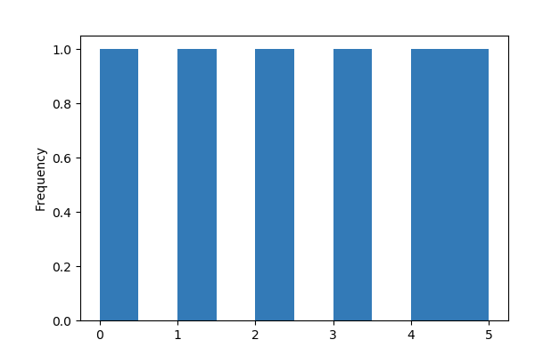

**Common Values**

| Value | Count | Frequency (%) |  |
| --- | --- | --- | --- |
| 5 | 1 | 16.7% |  |
| 4 | 1 | 16.7% |  |
| 3 | 1 | 16.7% |  |
| 2 | 1 | 16.7% |  |
| 1 | 1 | 16.7% |  |
| 0 | 1 | 16.7% |  |

**Extreme Values**

Minimum 5 values

| Value | Count | Frequency (%) |  |
| --- | --- | --- | --- |
| 0 | 1 | 16.7% |  |
| 1 | 1 | 16.7% |  |
| 2 | 1 | 16.7% |  |
| 3 | 1 | 16.7% |  |
| 4 | 1 | 16.7% |  |

Maximum 5 values

| Value | Count | Frequency (%) |  |
| --- | --- | --- | --- |
| 1 | 1 | 16.7% |  |
| 2 | 1 | 16.7% |  |
| 3 | 1 | 16.7% |  |
| 4 | 1 | 16.7% |  |
| 5 | 1 | 16.7% |  |

data2  
Numeric

| Distinct count | 5 |
| --- | --- |
| Unique (%) | 83.3% |
| Missing (%) | 0.0% |
| Missing (n) | 0 |
| Infinite (%) | 0.0% |
| Infinite (n) | 0 |

| Mean | 4.5 |
| --- | --- |
| Minimum | 0 |
| Maximum | 9 |
| Zeros (%) | 16.7% |

Toggle details

**Statistics**

Quantile statistics

| Minimum | 0 |
| --- | --- |
| 5-th percentile | 0.75 |
| Q1 | 3 |
| Median | 4 |
| Q3 | 6.5 |
| 95-th percentile | 8.5 |
| Maximum | 9 |
| Range | 9 |
| Interquartile range | 3.5 |

Descriptive statistics

| Standard deviation | 3.2094 |
| --- | --- |
| Coef of variation | 0.71319 |
| Kurtosis | -0.51371 |
| Mean | 4.5 |
| MAD | 2.5 |
| Skewness | 0.081679 |
| Sum | 27 |
| Variance | 10.3 |
| Memory size | 176.0 B |

**Histogram**

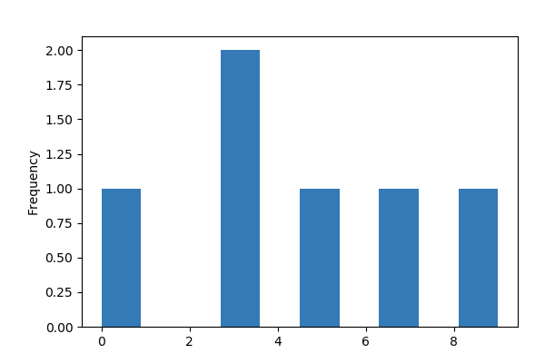

**Common Values**

| Value | Count | Frequency (%) |  |
| --- | --- | --- | --- |
| 3 | 2 | 33.3% |  |
| 7 | 1 | 16.7% |  |
| 5 | 1 | 16.7% |  |
| 9 | 1 | 16.7% |  |
| 0 | 1 | 16.7% |  |

**Extreme Values**

Minimum 5 values

| Value | Count | Frequency (%) |  |
| --- | --- | --- | --- |
| 0 | 1 | 16.7% |  |
| 3 | 2 | 33.3% |  |
| 5 | 1 | 16.7% |  |
| 7 | 1 | 16.7% |  |
| 9 | 1 | 16.7% |  |

Maximum 5 values

| Value | Count | Frequency (%) |  |
| --- | --- | --- | --- |
| 0 | 1 | 16.7% |  |
| 3 | 2 | 33.3% |  |
| 5 | 1 | 16.7% |  |
| 7 | 1 | 16.7% |  |
| 9 | 1 | 16.7% |  |

Correlations

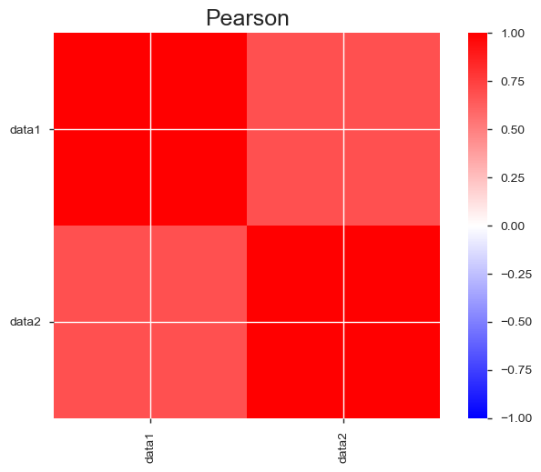

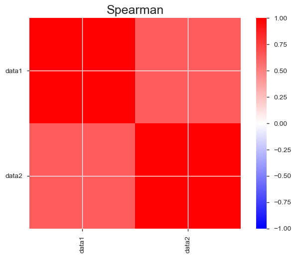

Sample

|  | key | data1 | data2 |
| --- | --- | --- | --- |
| 0 | A | 0 | 5 |
| 1 | B | 1 | 0 |
| 2 | C | 2 | 3 |
| 3 | A | 3 | 3 |
| 4 | B | 4 | 7 |

```python
# An exampel to use pandas-profiling to generate data profiling report
import pandas as pd
import numpy as np
import pandas_profiling as pp

rng = np.random.RandomState(0)
df = pd.DataFrame({'key': ['A', 'B', 'C', 'A', 'B', 'C'],
                   'data1': range(6),
                   'data2': rng.randint(0, 10, 6)},
                   columns = ['key', 'data1', 'data2'])

df.head()
pp.ProfileReport(df.reset_index(drop=True))
```